# 05: Dimensionality Reduction

← Prev: Gating Next: Clustering →

```r
library(flowWorkspace)
library(uwot)
library(ggplot2)
library(tidyverse)
```

```r
gs <- load_gs("data/processed/PBMC_gs_gated")
```

UMAP takes all your marker channels and compresses them into two dimensions, letting you visualise the overall structure of your data — which populations exist, how distinct they are, and how they relate to each other. For a PBMC panel with T cells, B cells, NK cells, and monocytes, each population should appear as a distinct cluster. This is an exploratory step, not an analytical one: what you see here should guide interpretation, not replace gating or statistics.

## Extract expression data

Run UMAP on the live singlet population — all immune cells before restricting to T cells only:

```r
marker_channels <- c("CD3_PB", "CD4_AF700", "CD8a_BV785",
                     "CD14_BV605", "CD19_APCCy7", "CD56_BV650",
                     "CD11c_BV711", "CD45RA_PECy7", "IgM_AF647")

live_data <- gs_pop_get_data(gs, "live")
expr_df   <- as.data.frame(exprs(live_data[[1]])[, marker_channels])
cat("Cells for UMAP:", nrow(expr_df), "\n")
```

```
## Cells for UMAP: 5555
```

## Run UMAP

```r
set.seed(42)
n_neighbors <- min(15, nrow(expr_df) - 1)
umap_coords <- umap(
  expr_df,
  n_neighbors = n_neighbors,
  min_dist    = 0.3,
  n_threads   = 1,
  verbose     = FALSE
)

umap_df <- expr_df %>%
  mutate(UMAP1 = umap_coords[, 1],
         UMAP2 = umap_coords[, 2])
```

## Marker plots

Colour the UMAP by each marker to understand what drives the structure. Regions with high expression of a marker should correspond to the populations you know those markers define.

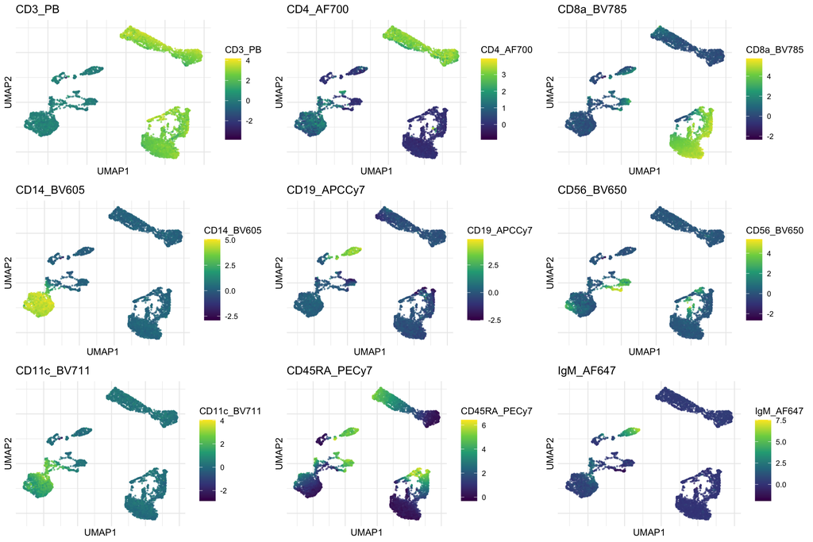

```r
plot_marker <- function(df, channel) {
  ggplot(df, aes(x = UMAP1, y = UMAP2, color = .data[[channel]])) +
    geom_point(size = 0.4, alpha = 0.6) +
    scale_color_viridis_c() +
    labs(title = channel) +
    theme_minimal(base_size = 10) +
    theme(legend.position = "right",
          axis.text = element_blank(),
          axis.ticks = element_blank())
}

plots <- lapply(marker_channels, function(ch) plot_marker(umap_df, ch))
gridExtra::grid.arrange(grobs = plots, ncol = 3)
```

Interpreting the UMAP: - **CD3-bright cluster** → T cells - **CD19-bright / IgM-bright region** → B cells - **CD56-bright region** → NK cells - **CD14-bright / CD11c-bright region** → monocytes and dendritic cells - **Within the T cell cluster:** CD4 and CD8 should occupy distinct sub-regions, with CD45RA marking naive and terminally differentiated effector subsets

```r
saveRDS(umap_df, "data/processed/PBMC_umap.rds")
```

← Prev: Gating Next: Clustering →